# ProblemSet7sol

## Fahri Ulkat 090220756

## Question 1

**a. Ommited variable bias:** If the model excludes an important variable that is related to the independent variables, the estimates may be misleading and lead to incorrect results.

**b. Partial effect:** When other regressors are constant, the effect on Y of a change in relevant independent variable X.

**c. R2 and Adjusted R2:**

R^2 shows how much the independent variables explain the variance in the dependent variable. It has a value between 0 and 1.

Adjusted R^2: Since when a new variable added, an increase in R^2 is inevitable we need a better measure. Adjusted R^2 measures more accurately by taking into account the number of variables in the model and this measre does not have to increase when we add anothe regressor because of penaltization.

**d. Perfect multicollinearity:** An independent variable is a linear function of one or more other variables. This causes the model to fail to give accurate results.

**e.Dummy variable trap:** Including all dummy variables for a category would lead to perfect multicollinearity, making the model invalid.

**f. Imperfect multicollinearity:** It occurs when there is a high but imperfect linear relationship between independent variables. This can increase the magnitude of standard errors and make estimation difficult.

## Question 2

Following questions refer to the estimation results in Table 1 below, computed using data for 2015 from the Current Population Survey. The dataset consists of information on 7178 full-time full-year workers. The highest educational achievement for each worker was a bachelor’s degree. Let AHE denote average hourly earnings, college denote a binary variable that equals 1 if worker has a bachelor’s degree, equals 0 otherwise; age denote age in years. Also, there are four regional dummies, and the regional dummies northeast, midwest, south and west.

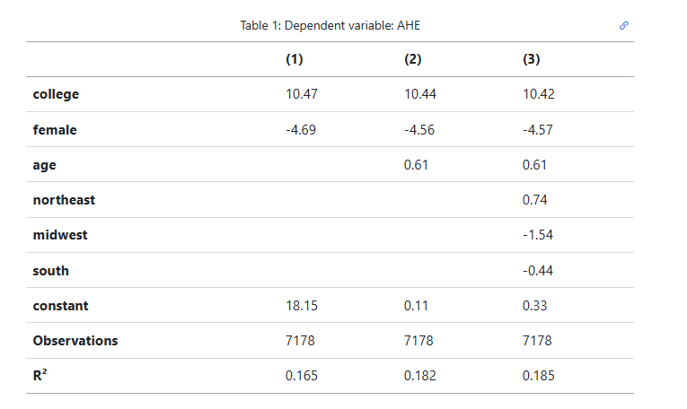

```python
from IPython.display import Image, display

display(Image("Screenshot_6.png"))
```

**a. Do workers with college degrees earn more on average than workers with no college degree? How much more? Do men earn more than women on average? How much more?**

Workers with colloge degrees earn **$10.47** more on avarage than workers with no colloge. The coefficient for female is -4.69 which means women earn **$4.69** less than men.

**b. Why is the regressor West omitted from the regression? What would happen if it was included?**

If we include "west", **dummy variable trap** will occur and it will cause perfect multicollinearity.

**c. Juanita is a 28-year-old female college graduate from the South. Jennifer is a 28-year-old female college graduate from the Midwest. Calculate the expected difference in earnings between Juanita and Jennifer.**

Since they are both 28 years old and females, the difference will occur just because of region difference which is **-0.44 - (-1.54) = $1.10**